# Lab 1

Author

Sahil Bains

Github Link: https://github.com/sbains2/GSB544

## Task 1

1. This chart shows life expectancy measured by income, where the y-axis represents life expectancy (in years), and x-axis represents income (GDP per capita). The variables that are mapped so that the color represents a region, where each dot represents a specific country. The size of the bubbles represents the population.

```python
import pandas as pd
import numpy as np
from plotnine import *


# Importing datasets as csv's
df1 = pd.read_csv('q1.csv')
df2 = pd.read_csv('q2.csv')
df3 = pd.read_csv('q3.csv')

df1.info()
```

```
<class 'pandas.core.frame.DataFrame'>
RangeIndex: 197 entries, 0 to 196
Data columns (total 9 columns):
 #   Column             Non-Null Count  Dtype
---  ------             --------------  -----
 0   income             195 non-null    float64
 1   life_exp           195 non-null    float64
 2   population         195 non-null    float64
 3   year               197 non-null    int64
 4   country            197 non-null    object
 5   four_regions       193 non-null    object
 6   six_regions        193 non-null    object
 7   eight_regions      193 non-null    object
 8   world_bank_region  193 non-null    object
dtypes: float64(3), int64(1), object(5)
memory usage: 14.0+ KB
```

3. Recreating the plot

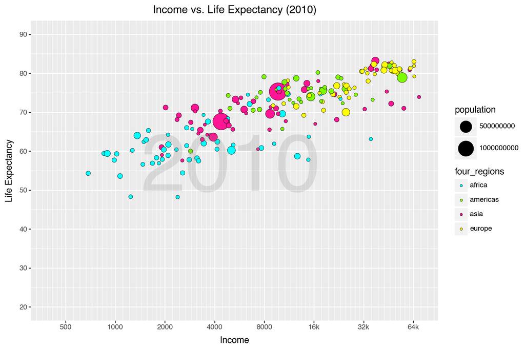

```python
# Subsetting for 2010 and normalizing data
df2010 = df1[(df1['year'] == 2010) & df1['four_regions'].notna()]

# Specifying breaks for xticks and yticks
x_breaks = [500, 1000, 2000, 4000, 8000, 16000, 32000, 64000]
x_labels = ['500', '1000', '2000', '4000', '8000', '16k', '32k', '64k']
y_breaks = [20, 30, 40, 50, 60, 70, 80, 90]
y_labels = ['20', '30', '40', '50', '60', '70', '80', '90']

# Defining the colors for each region
regions_four = {
    'asia': 'deeppink',
    'americas': 'lawngreen',
    'europe': 'yellow',
    'africa': 'cyan'
}

(
    ggplot(df2010, aes(x='income', y='life_exp', size='population', fill='four_regions'))
    + scale_x_continuous(trans='log10', limits=(400, 70000), breaks=x_breaks, labels=x_labels)
    + scale_y_continuous(limits=(20, 90), breaks=y_breaks, labels=y_labels)
    + geom_point(show_legend=True, color='black', stroke=.2)
    + labs(
        x='Income',
        y='Life Expectancy',
        color='Region',
        title='Income vs. Life Expectancy (2010)')
    + scale_size(range=(2,12), guide='legend')
    # Making the chart taller so vertical scale doesn't condense values
    + theme(figure_size=(9,6))
    + scale_fill_manual(values=regions_four)
    + annotate(geom='text', x=5000, y=55, label='2010', size=100, alpha=0.2, color='gray')

)
```

Process for rebuilding the plots: - Filtering: Subsetted the data so it’s only from the year 2010 with a valid region so that the legend or the plot doesn’t include ‘nan’ - Scales: To match the gapminder spread, I used the scale_x_continuous() function with custom breaks and labels. - Colors: In order to match the color palette of the gapminder graph, I specified a manual palette via the scale_fill_manual() - Annotation: I added the annotation line in order to incldue the year in the backdrop to match the gapminder plot

4. Using other geometries

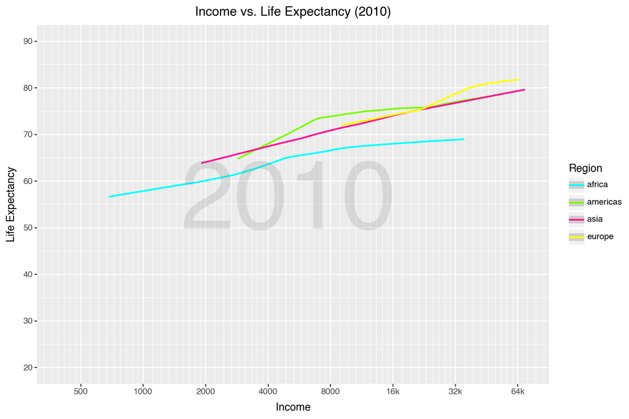

```python
# Subsetting for 2010 and normalizing data
df2010 = df1[(df1['year'] == 2010) & df1['four_regions'].notna()]

# Specifying breaks for xticks and yticks
x_breaks = [500, 1000, 2000, 4000, 8000, 16000, 32000, 64000]
x_labels = ['500', '1000', '2000', '4000', '8000', '16k', '32k', '64k']
y_breaks = [20, 30, 40, 50, 60, 70, 80, 90]
y_labels = ['20', '30', '40', '50', '60', '70', '80', '90']

# Defining the colors for each region
regions_four = {
    'asia': 'deeppink',
    'americas': 'lawngreen',
    'europe': 'yellow',
    'africa': 'cyan'
}


(
    ggplot(df2010, aes(x='income', y='life_exp', size='population', color='four_regions'))
    + scale_x_continuous(trans='log10', limits=(400, 70000), breaks=x_breaks, labels=x_labels)
    + scale_y_continuous(limits=(20, 90), breaks=y_breaks, labels=y_labels)
    + geom_smooth(show_legend=True)
    + labs(
        x='Income',
        y='Life Expectancy',
        color='Region',
        title='Income vs. Life Expectancy (2010)')
    + scale_size(range=(2,12), guide='legend')
    # Making the chart taller so vertical scale doesn't condense values
    + theme(figure_size=(9,6))
    + scale_color_manual(values=regions_four)
    + annotate(geom='text', x=5000, y=55, label='2010', size=100, alpha=0.2, color='gray')

)
```

Here, we use the geom_smooth plotting function in order to plot the life expectancy with income. Geom_smooth() shows an average trend by region but hides the country-level variation and population differences, so it’s not ideal. Overall, geom_point is best for understanding how each country sits with income and life expectancy.

## Task 2

1. Aesthetics explanation Here, the x-axis aesthetic is mapped to the exports as the percentage of each country’s GDP, and the y-axis aesthetic is mapped to the imports as a percentage of each country’s GDP. The size of each bubble corresponds to energy use, while the color represents the world region each country belongs to. Each bubble represents a single country in the year shown, which allows comparisons across both trade and energy consumption, with the regions being indicated by the color.
2. Importing q2 data

```python
df2 = pd.read_csv('q2.csv')
df2.info()
```

```
<class 'pandas.core.frame.DataFrame'>
RangeIndex: 206 entries, 0 to 205
Data columns (total 9 columns):
 #   Column             Non-Null Count  Dtype
---  ------             --------------  -----
 0   imports            171 non-null    float64
 1   exports            171 non-null    float64
 2   energy             137 non-null    object
 3   year               206 non-null    int64
 4   country            206 non-null    object
 5   four_regions       182 non-null    object
 6   six_regions        182 non-null    object
 7   eight_regions      182 non-null    object
 8   world_bank_region  182 non-null    object
dtypes: float64(2), int64(1), object(6)
memory usage: 14.6+ KB
```

3. Recreating the plot using plotnine

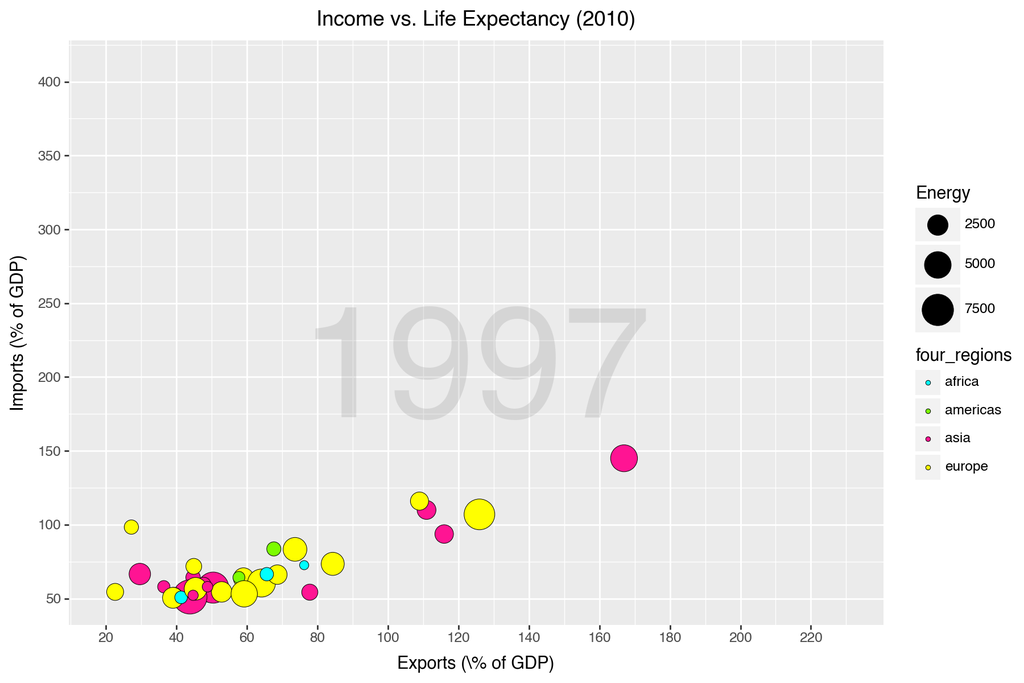

```python
# Subsetting for 1997 and normalizing data
df1997 = df2[(df2['year'] == 1997) & df2['four_regions'].notna()]
df1997['energy'] = pd.to_numeric(df1997['energy'], errors='coerce') # Changing energy column to numeric, invalids turn into NaN
df1997 = df1997.dropna()

# Defining the colors for each region
regions_four = {
    'asia': 'deeppink',
    'americas': 'lawngreen',
    'europe': 'yellow',
    'africa': 'cyan'
}

# Specifying breaks for xticks and yticks
x_breaks = range(20, 221, 20)
x_labels = ['20', '40', '60', '80', '100', '120', '140', '160', '180', '200', '220']
y_breaks = range(50, 401, 50)
y_labels = ['50', '100', '150', '200', '250', '300', '350', '400']

(
    ggplot(df1997, aes(x='exports', y='imports', size='energy', fill='four_regions'))
    + scale_x_continuous(limits=(20, 230), breaks=x_breaks, labels=x_labels)
    + scale_y_continuous(limits=(50, 410), breaks=y_breaks, labels=y_labels)
    + geom_point(show_legend=True, color='black', stroke=.2)
    + labs(
        x="Exports (\% of GDP)",
        y="Imports (\% of GDP)",
        color='Region',
        size='Energy',
        title='Income vs. Life Expectancy (2010)')
    + scale_size(range=(2,12), guide='legend')
    # Making the chart taller so vertical scale doesn't condense values
    + theme(figure_size=(9,6))
    + scale_fill_manual(values=regions_four)
    + annotate(geom='text', x=125, y=200, label='1997', size=100, alpha=0.2, color='gray')

)
```

Process for Rebuilding the plot: - Type fix: I transformed energy to numeric as it was showing non-numeric for some rows - Filtering: I called dropna() so that rows that had missing mapped aesthetics don’t get dropped by the layer

4. Using other geometries

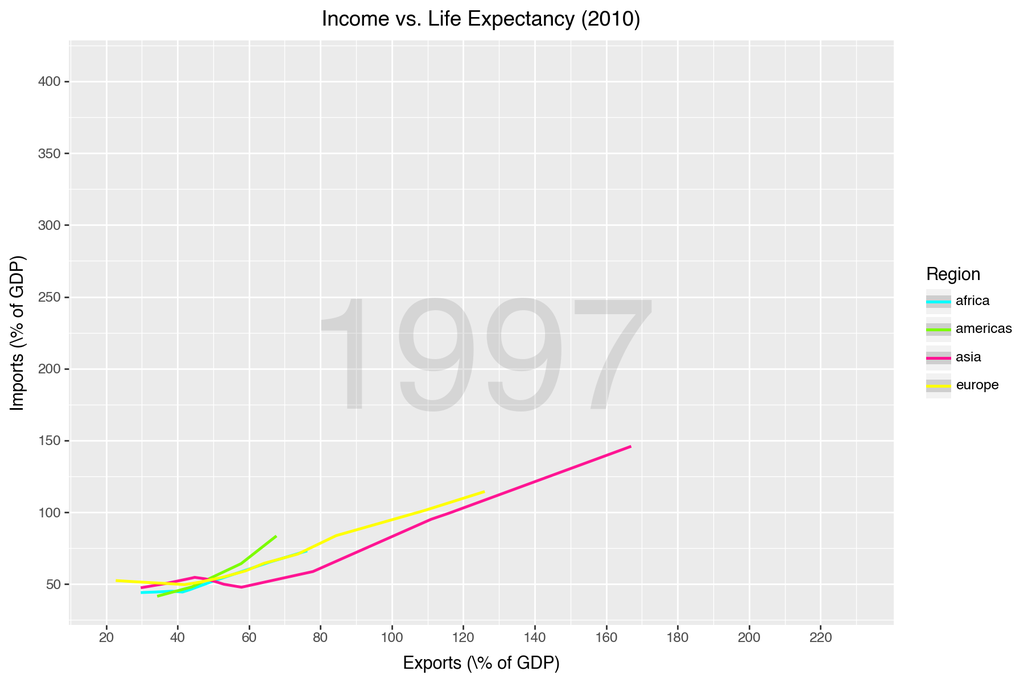

```python
# Subsetting for 1997 and normalizing data
df1997 = df2[(df2['year'] == 1997) & df2['four_regions'].notna()]
df1997['energy'] = pd.to_numeric(df1997['energy'], errors='coerce') # Changing energy column to numeric, invalids turn into NaN
df1997 = df1997.dropna()

# Defining the colors for each region
regions_four = {
    'asia': 'deeppink',
    'americas': 'lawngreen',
    'europe': 'yellow',
    'africa': 'cyan'
}

# Specifying breaks for xticks and yticks
x_breaks = range(20, 221, 20)
x_labels = ['20', '40', '60', '80', '100', '120', '140', '160', '180', '200', '220']
y_breaks = range(50, 401, 50)
y_labels = ['50', '100', '150', '200', '250', '300', '350', '400']

(
    ggplot(df1997, aes(x='exports', y='imports', size='energy', color='four_regions'))
    + scale_x_continuous(limits=(20, 230), breaks=x_breaks, labels=x_labels)
    + scale_y_continuous(limits=(40, 410), breaks=y_breaks, labels=y_labels)
    + geom_smooth(show_legend=True)
    + labs(
        x="Exports (\% of GDP)",
        y="Imports (\% of GDP)",
        color='Region',
        size='Energy',
        title='Income vs. Life Expectancy (2010)')
    + scale_size(range=(2,12), guide='legend')
    # Making the chart taller so vertical scale doesn't condense values
    + theme(figure_size=(9,6))
    + annotate(geom='text', x=125, y=200, label='1997', size=100, alpha=0.2, color='gray')
    + scale_color_manual(values=regions_four)

)
```

Explanation: Similarly to task 1, geom_smooth() summarizes the trends by region but doesn’t visualize country-level spread and the corresponding outliers. geom_point() is optimal in this case for representing all of the aesthetics that are used.

## Task 3

1. Here, the x-axis aesthetic is being mapped to individuals using the internet (%), and the y-axis aesthetic is being mapped to the GDP per capita. The size of each bubble represents income, while the color of the bubble corresponds to the world region that each country belongs to.
2. importing the data

```python
df3 = pd.read_csv('q3.csv')
df3.info()
```

```
<class 'pandas.core.frame.DataFrame'>
RangeIndex: 215 entries, 0 to 214
Data columns (total 9 columns):
 #   Column             Non-Null Count  Dtype
---  ------             --------------  -----
 0   internet_users     200 non-null    float64
 1   gdp                199 non-null    float64
 2   income             195 non-null    float64
 3   year               215 non-null    int64
 4   country            215 non-null    object
 5   four_regions       193 non-null    object
 6   six_regions        193 non-null    object
 7   eight_regions      193 non-null    object
 8   world_bank_region  193 non-null    object
dtypes: float64(3), int64(1), object(5)
memory usage: 15.2+ KB
```

3. Recreating the plot

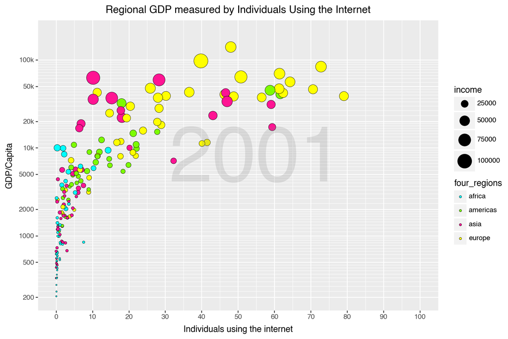

```python
# Subsetting for 2001 and normalizing data
df2001 = df3[(df3['year'] == 2001)]
df2001 = df2001.dropna(subset=('internet_users', 'gdp', 'income', 'four_regions'))

# Specifying breaks for xticks and yticks
x_breaks = list(range(0, 101, 10))
x_labels = ['0', '10', '20', '30', '40', '50', '60', '70', '80', '90', '100']
y_breaks = [200, 500, 1000, 2000, 5000, 10000, 20000, 50000, 100000]
y_labels = ['200', '500', '1000', '2000', '5000', '10k', '20k', '50k', '100k']

# Defining the colors for each region
regions_four = {
    'asia': 'deeppink',
    'americas': 'lawngreen',
    'europe': 'yellow',
    'africa': 'cyan'
}

(
    ggplot(df2001, aes(x='internet_users', y='gdp', size='income', fill='four_regions'))
    + scale_x_continuous(limits=(0, 100), breaks=x_breaks, labels=x_labels)
    + scale_y_continuous(trans='log10', limits=(200, 200000), breaks=y_breaks, labels=y_labels)
    + geom_point(show_legend=True, shape='o', color='black', stroke=.2)
    + labs(
        x="Individuals using the internet",
        y="GDP/Capita",
        color='Region',
        size='income',
        title='Regional GDP measured by Individuals Using the Internet')
    + scale_size_area(max_size=10, guide='legend')
    # Making the chart taller so vertical scale doesn't condense values
    + theme(figure_size=(9,6))
    + annotate(geom='text', x=55, y=7000, label='2001', size=100, alpha=0.2, color='gray')
    + scale_fill_manual(values=regions_four)


)
```

Process for rebuilding the plot: - Scales: Y: Used the scale_y_continuous(trans=log10) in order to visualize the low and high GDP countries

4. Using other geometries

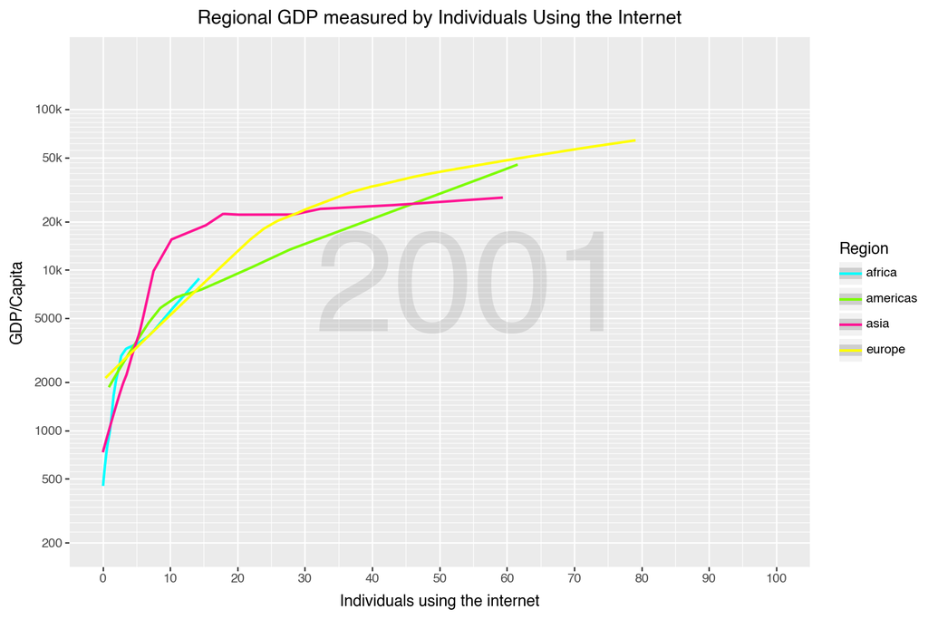

```python
# Subsetting for 2001 and normalizing data
df2001 = df3[(df3['year'] == 2001)]
df2001 = df2001.dropna(subset=('internet_users', 'gdp', 'income', 'four_regions'))

# Specifying breaks for xticks and yticks
x_breaks = list(range(0, 101, 10))
x_labels = ['0', '10', '20', '30', '40', '50', '60', '70', '80', '90', '100']
y_breaks = [200, 500, 1000, 2000, 5000, 10000, 20000, 50000, 100000]
y_labels = ['200', '500', '1000', '2000', '5000', '10k', '20k', '50k', '100k']

# Defining the colors for each region
regions_four = {
    'asia': 'deeppink',
    'americas': 'lawngreen',
    'europe': 'yellow',
    'africa': 'cyan'
}

(
    ggplot(df2001, aes(x='internet_users', y='gdp', size='income', color='four_regions'))
    + scale_x_continuous(limits=(0, 100), breaks=x_breaks, labels=x_labels)
    + scale_y_continuous(trans='log10', limits=(200, 200000), breaks=y_breaks, labels=y_labels)
    + geom_smooth(show_legend=True)
    + labs(
        x="Individuals using the internet",
        y="GDP/Capita",
        color='Region',
        size='income',
        title='Regional GDP measured by Individuals Using the Internet')
    + scale_size_area(max_size=10, guide='legend')
    # Making the chart taller so vertical scale doesn't condense values
    + theme(figure_size=(9,6))
    + annotate(geom='text', x=55, y=7000, label='2001', size=100, alpha=0.2, color='gray')
    + scale_color_manual(values=regions_four)


)
```

Explanation: Overall, geom_smooth captures the upward trend of internet use and GDP however it doesn’t include the cross country variation as well as the regional differences in the bubbles. Here, it would be more effective to use geom_point for multi-variable comparison.